# Olympics is the biggest atheltics competition that brings about all the countries in the world

### The Analysis will dig deeper to find out how the medals distribution has been since the inception of the competition

#### We shall be looking and trying to answer the below

1. The most successful countries
2. Most sucessful athletes
3. Best attended fields
4. Gender representation

# *Data files will be athletes infromation and NOC contries*

*Analysis will we performed using the python langauge with libaries of choice including

> **Pandas - Data manipulation**

> **Matplotlib - Visualization**

> **Seaborn - Visualization**

```python
#Importing the libraries to be used
#Warnings will be used to ignore the warning that pop up
import warnings

import pandas as pd
import matplotlib.pyplot as plt
import seaborn as sns

warnings.filterwarnings('ignore')
```

```python
#Athletes  and NOC data

athletes = pd.read_csv("athlete_events.csv", encoding='ISO-8859-1')
noc = pd.read_csv("noc_regions.csv")
```

```python
#Checking data NOC countries
noc.head(5)
```

|  | NOC | region | notes |
| --- | --- | --- | --- |
| 0 | AFG | Afghanistan | NaN |
| 1 | AHO | Curacao | Netherlands Antilles |
| 2 | ALB | Albania | NaN |
| 3 | ALG | Algeria | NaN |
| 4 | AND | Andorra | NaN |

```python
#Checking athletes data
athletes.head(5)
```

|  | ID | Name | Sex | Age | Height | Weight | Team | NOC | Games | Year | Season | City | Sport | Event | Medal |
| --- | --- | --- | --- | --- | --- | --- | --- | --- | --- | --- | --- | --- | --- | --- | --- |
| 0 | 1 | A Dijiang | M | 24.0 | 180.0 | 80.0 | China | CHN | 1992 Summer | 1992 | Summer | Barcelona | Basketball | Basketball Men's Basketball | NaN |
| 1 | 2 | A Lamusi | M | 23.0 | 170.0 | 60.0 | China | CHN | 2012 Summer | 2012 | Summer | London | Judo | Judo Men's Extra-Lightweight | NaN |
| 2 | 3 | Gunnar Nielsen Aaby | M | 24.0 | NaN | NaN | Denmark | DEN | 1920 Summer | 1920 | Summer | Antwerpen | Football | Football Men's Football | NaN |
| 3 | 4 | Edgar Lindenau Aabye | M | 34.0 | NaN | NaN | Denmark/Sweden | DEN | 1900 Summer | 1900 | Summer | Paris | Tug-Of-War | Tug-Of-War Men's Tug-Of-War | Gold |
| 4 | 5 | Christine Jacoba Aaftink | F | 21.0 | 185.0 | 82.0 | Netherlands | NED | 1988 Winter | 1988 | Winter | Calgary | Speed Skating | Speed Skating Women's 500 metres | NaN |

```python
#size of the data files
noc_size = noc.shape
atheletes_size = athletes.shape

print(f"Data size are as below:\n Noc: {noc_size}\n Athletes: {atheletes_size}")
```

```
Data size are as below:
 Noc: (230, 3)
 Athletes: (271116, 15)
```

```python
# Joining the tables to ensure we have the correct name of the country

complete_data = pd.merge(athletes, noc, on="NOC")
```

```python
# Merged Data
complete_data.head(5)
```

|  | ID | Name | Sex | Age | Height | Weight | Team | NOC | Games | Year | Season | City | Sport | Event | Medal | region | notes |
| --- | --- | --- | --- | --- | --- | --- | --- | --- | --- | --- | --- | --- | --- | --- | --- | --- | --- |
| 0 | 1 | A Dijiang | M | 24.0 | 180.0 | 80.0 | China | CHN | 1992 Summer | 1992 | Summer | Barcelona | Basketball | Basketball Men's Basketball | NaN | China | NaN |
| 1 | 2 | A Lamusi | M | 23.0 | 170.0 | 60.0 | China | CHN | 2012 Summer | 2012 | Summer | London | Judo | Judo Men's Extra-Lightweight | NaN | China | NaN |
| 2 | 602 | Abudoureheman | M | 22.0 | 182.0 | 75.0 | China | CHN | 2000 Summer | 2000 | Summer | Sydney | Boxing | Boxing Men's Middleweight | NaN | China | NaN |
| 3 | 1463 | Ai Linuer | M | 25.0 | 160.0 | 62.0 | China | CHN | 2004 Summer | 2004 | Summer | Athina | Wrestling | Wrestling Men's Lightweight, Greco-Roman | NaN | China | NaN |
| 4 | 1464 | Ai Yanhan | F | 14.0 | 168.0 | 54.0 | China | CHN | 2016 Summer | 2016 | Summer | Rio de Janeiro | Swimming | Swimming Women's 200 metres Freestyle | NaN | China | NaN |

```python
# We don't need the the notes column, the same was inherited as merging was done between the 2 datasets
complete_data_new = complete_data.iloc[:,0:len(complete_data.columns)-1]
```

```python
complete_data_new.head(5)
```

|  | ID | Name | Sex | Age | Height | Weight | Team | NOC | Games | Year | Season | City | Sport | Event | Medal | region |
| --- | --- | --- | --- | --- | --- | --- | --- | --- | --- | --- | --- | --- | --- | --- | --- | --- |
| 0 | 1 | A Dijiang | M | 24.0 | 180.0 | 80.0 | China | CHN | 1992 Summer | 1992 | Summer | Barcelona | Basketball | Basketball Men's Basketball | NaN | China |
| 1 | 2 | A Lamusi | M | 23.0 | 170.0 | 60.0 | China | CHN | 2012 Summer | 2012 | Summer | London | Judo | Judo Men's Extra-Lightweight | NaN | China |
| 2 | 602 | Abudoureheman | M | 22.0 | 182.0 | 75.0 | China | CHN | 2000 Summer | 2000 | Summer | Sydney | Boxing | Boxing Men's Middleweight | NaN | China |
| 3 | 1463 | Ai Linuer | M | 25.0 | 160.0 | 62.0 | China | CHN | 2004 Summer | 2004 | Summer | Athina | Wrestling | Wrestling Men's Lightweight, Greco-Roman | NaN | China |
| 4 | 1464 | Ai Yanhan | F | 14.0 | 168.0 | 54.0 | China | CHN | 2016 Summer | 2016 | Summer | Rio de Janeiro | Swimming | Swimming Women's 200 metres Freestyle | NaN | China |

### Over and above reviewing details mentioned in the headed, there is much more that can be gathered from the data.

##### Additional analysis to be done will be:

1. Host countries
2. Average age height weight for the various fields
3. Any Additional information that will come along the way.

```python
# host countries
complete_data_new.head(5)
```

|  | ID | Name | Sex | Age | Height | Weight | Team | NOC | Games | Year | Season | City | Sport | Event | Medal | region |
| --- | --- | --- | --- | --- | --- | --- | --- | --- | --- | --- | --- | --- | --- | --- | --- | --- |
| 0 | 1 | A Dijiang | M | 24.0 | 180.0 | 80.0 | China | CHN | 1992 Summer | 1992 | Summer | Barcelona | Basketball | Basketball Men's Basketball | NaN | China |
| 1 | 2 | A Lamusi | M | 23.0 | 170.0 | 60.0 | China | CHN | 2012 Summer | 2012 | Summer | London | Judo | Judo Men's Extra-Lightweight | NaN | China |
| 2 | 602 | Abudoureheman | M | 22.0 | 182.0 | 75.0 | China | CHN | 2000 Summer | 2000 | Summer | Sydney | Boxing | Boxing Men's Middleweight | NaN | China |
| 3 | 1463 | Ai Linuer | M | 25.0 | 160.0 | 62.0 | China | CHN | 2004 Summer | 2004 | Summer | Athina | Wrestling | Wrestling Men's Lightweight, Greco-Roman | NaN | China |
| 4 | 1464 | Ai Yanhan | F | 14.0 | 168.0 | 54.0 | China | CHN | 2016 Summer | 2016 | Summer | Rio de Janeiro | Swimming | Swimming Women's 200 metres Freestyle | NaN | China |

```python
# Unique number of atheletes
unique_athletes = complete_data_new["Name"].unique()
print(f"Total number of athletes to participate in the olympics: {len(unique_athletes)} ")
```

```
Total number of athletes to participate in the olympics: 134566
```

```python
# Unique teams/countries
countries = len(complete_data_new["region"].unique())
print(f"The countries to have participated in the olympics competition: {countries}")
```

```
The countries to have participated in the olympics competition: 206
```

```python
# cities to have participated
cities = complete_data_new["City"].unique()
print(f"The countries to have hosted the competition: {len(cities)}")
```

[output not shown]

```python
# Sports activities
sports = complete_data_new["Sport"].unique()
print(f"The sports disciplines: {len(sports)}")
```

```
The sports disciplines: 66
```

```python
# Gender comparison

gender = pd.pivot_table(complete_data_new,
                        values="Name",
                        index=["Sex"],
                        aggfunc="count")
gender
```

| Sex | Name |
| --- | --- |
| F | 74393 |
| M | 196374 |

#### *Ever since inception, the competition has registered more males than females*

```python
latest_year = complete_data_new["Year"].max()
first_year = complete_data_new["Year"].min()
print(f"The analysis will cover between: {first_year}-{latest_year}")
```

```
The analysis will cover between: 1896-2016
```

```python
# Number of competitors per year
complete_data_new[["Year", "Name"]].groupby("Year").count().sort_values(by="Name", ascending=False)
```

| Year | Name |
| --- | --- |
| 1992 | 16376 |
| 1988 | 14649 |
| 2000 | 13798 |
| 1996 | 13745 |
| 2016 | 13656 |
| 2008 | 13566 |
| 2004 | 13421 |
| 2012 | 12884 |
| 1972 | 11947 |
| 1984 | 11574 |
| 1976 | 10498 |
| 1968 | 10473 |
| 1964 | 9480 |
| 1952 | 9351 |
| 1960 | 9230 |
| 1980 | 8937 |
| 1948 | 7479 |
| 1936 | 7401 |
| 1956 | 6382 |
| 1924 | 5693 |
| 1928 | 5574 |
| 2014 | 4891 |
| 2010 | 4402 |
| 2006 | 4382 |
| 1920 | 4292 |
| 2002 | 4109 |
| 1912 | 4040 |
| 1998 | 3605 |
| 1932 | 3321 |
| 1994 | 3160 |
| 1908 | 3101 |
| 1900 | 1936 |
| 1906 | 1733 |
| 1904 | 1301 |
| 1896 | 380 |

### Participation by year

```python
complete_data_new.columns
```

```
Index(['ID', 'Name', 'Sex', 'Age', 'Height', 'Weight', 'Team', 'NOC', 'Games',
       'Year', 'Season', 'City', 'Sport', 'Event', 'Medal', 'region'],
      dtype='object')
```

```python
# Medal standing
medal_standing = complete_data_new.groupby("region")["Medal"].value_counts(dropna=False).unstack(fill_value=0)[["Gold", "Silver", "Bronze"]]
medal_standing["Totals"] = medal_standing["Gold"] + medal_standing["Silver"] + medal_standing["Bronze"]
```

### *Top 20 countries in the medal standing*

```python
medal_standing.sort_values(by="Totals", ascending=False).head(20)
```

| Medal region | Gold | Silver | Bronze | Totals |
| --- | --- | --- | --- | --- |
| USA | 2638 | 1641 | 1358 | 5637 |
| Russia | 1599 | 1170 | 1178 | 3947 |
| Germany | 1301 | 1195 | 1260 | 3756 |
| UK | 678 | 739 | 651 | 2068 |
| France | 501 | 610 | 666 | 1777 |
| Italy | 575 | 531 | 531 | 1637 |
| Sweden | 479 | 522 | 535 | 1536 |
| Canada | 463 | 438 | 451 | 1352 |
| Australia | 368 | 459 | 522 | 1349 |
| Hungary | 432 | 332 | 371 | 1135 |
| Netherlands | 287 | 340 | 413 | 1040 |
| Norway | 378 | 361 | 294 | 1033 |
| China | 351 | 349 | 293 | 993 |
| Japan | 247 | 309 | 357 | 913 |
| Finland | 198 | 270 | 432 | 900 |
| Switzerland | 175 | 248 | 268 | 691 |
| Romania | 161 | 200 | 292 | 653 |
| Czech Republic | 123 | 262 | 259 | 644 |
| South Korea | 221 | 232 | 185 | 638 |
| Denmark | 179 | 241 | 177 | 597 |

```python
medal_stand = medal_standing.sort_values(by="Totals", ascending=False)
```

### Countries with medals

```python
countries_with_medals=medal_stand[medal_stand["Totals"] >= 1]
medal_count = countries_with_medals["Totals"].count()
print(f"Countries to have won medals since are: {medal_count} in total")
```

```
Countries to have won medals since are: 136 in total
```

### Never won medals

```python
countries_without_medals = medal_stand[medal_stand["Totals"]==0]
medal_count_0 = countries_without_medals["Totals"].count()
print(f"Countries that have never won a medal are: {medal_count_0} in total.")
```

```
Countries that have never won a medal are: 69 in total.
```

```python
display(countries_without_medals.to_string())
```

[output not shown]

### Notes

1. The details could have changed since the data is to 2016
2. Some of the countries could have won medals

```python
top_20 = medal_stand[0:20]
top_20["Totals"]
```

```
region
USA               5637
Russia            3947
Germany           3756
UK                2068
France            1777
Italy             1637
Sweden            1536
Canada            1352
Australia         1349
Hungary           1135
Netherlands       1040
Norway            1033
China              993
Japan              913
Finland            900
Switzerland        691
Romania            653
Czech Republic     644
South Korea        638
Denmark            597
Name: Totals, dtype: int64
```

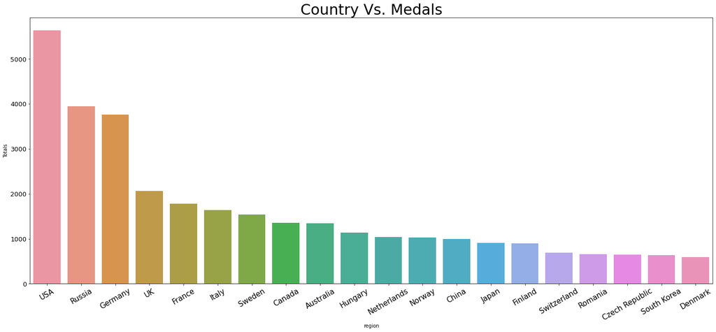

```python
fig = plt.figure(figsize=(25, 10))
g = sns.barplot(x = top_20.index, y = top_20["Totals"])
g.set_xticklabels(rotation = 30,
                 labels = top_20.index)
g.set_title ("Country Vs. Medals", fontdict={'size': 30})
plt.xticks(fontsize = 15)
plt.yticks(fontsize= 13)
plt.show()
```

```python
complete_data_new["Sport"].unique()
```

```
array(['Basketball', 'Judo', 'Boxing', 'Wrestling', 'Swimming',
       'Speed Skating', 'Short Track Speed Skating', 'Softball', 'Hockey',
       'Curling', 'Archery', 'Triathlon', 'Football',
       'Rhythmic Gymnastics', 'Athletics', 'Badminton', 'Fencing',
       'Figure Skating', 'Gymnastics', 'Volleyball', 'Baseball',
       'Water Polo', 'Snowboarding', 'Shooting', 'Weightlifting',
       'Cycling', 'Rowing', 'Sailing', 'Diving', 'Modern Pentathlon',
       'Art Competitions', 'Synchronized Swimming', 'Handball',
       'Canoeing', 'Cross Country Skiing', 'Table Tennis', 'Ice Hockey',
       'Tennis', 'Taekwondo', 'Freestyle Skiing', 'Beach Volleyball',
       'Trampolining', 'Alpine Skiing', 'Golf', 'Biathlon',
       'Equestrianism', 'Ski Jumping', 'Tug-Of-War', 'Bobsleigh',
       'Nordic Combined', 'Polo', 'Skeleton', 'Rugby Sevens', 'Luge',
       'Roque', 'Rugby', 'Lacrosse', 'Jeu De Paume',
       'Military Ski Patrol', 'Cricket', 'Croquet', 'Motorboating',
       'Basque Pelota', 'Alpinism', 'Aeronautics', 'Racquets'],
      dtype=object)
```

### Kenya features in the top 50 countries with 106 medals

```python
top_50 = medal_stand.iloc[20:50]["Totals"]
```

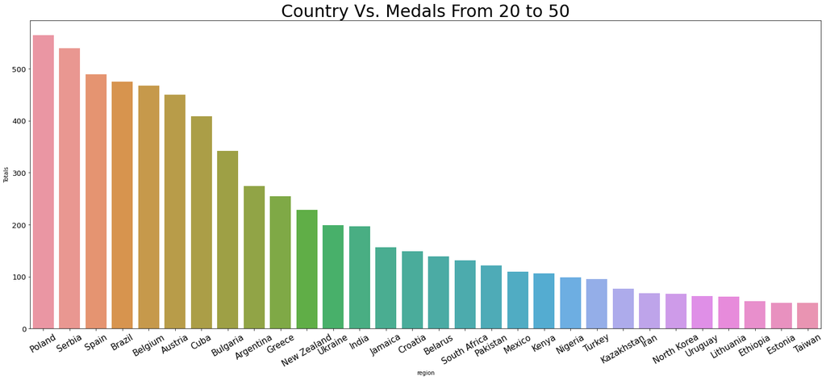

```python
fig = plt.figure(figsize=(25, 10))
g = sns.barplot(x = top_50.index, y = top_50[0:])
g.set_xticklabels(rotation = 30,
                 labels = top_50.index)
g.set_title ("Country Vs. Medals From 20 to 50", fontdict={'size': 30})
plt.xticks(fontsize = 15)
plt.yticks(fontsize= 13)
plt.show()
```

**Sports of interest**

1. *Athletics*
2. *Football*
3. *Tennis*

### Football

*The sports has a huge number of supports and followers, it is vital to learn how the countries have faired in the competition*

```python
football = complete_data_new[complete_data_new["Sport"]=="Football"]
football.head()
```

|  | ID | Name | Sex | Age | Height | Weight | Team | NOC | Games | Year | Season | City | Sport | Event | Medal | region |
| --- | --- | --- | --- | --- | --- | --- | --- | --- | --- | --- | --- | --- | --- | --- | --- | --- |
| 24 | 6851 | Bai Jie | F | 28.0 | 163.0 | 53.0 | China | CHN | 2000 Summer | 2000 | Summer | Sydney | Football | Football Women's Football | NaN | China |
| 25 | 6853 | Bai Lili | F | 25.0 | 168.0 | 57.0 | China | CHN | 2004 Summer | 2004 | Summer | Athina | Football | Football Women's Football | NaN | China |
| 31 | 7596 | Bao Jiaping | M | 27.0 | 177.0 | 55.0 | China | CHN | 1936 Summer | 1936 | Summer | Berlin | Football | Football Men's Football | NaN | China |
| 43 | 11224 | Bi Yan | F | 20.0 | 170.0 | 62.0 | China | CHN | 2004 Summer | 2004 | Summer | Athina | Football | Football Women's Football | NaN | China |
| 44 | 11224 | Bi Yan | F | 24.0 | 170.0 | 62.0 | China | CHN | 2008 Summer | 2008 | Summer | Beijing | Football | Football Women's Football | NaN | China |

```python
football_medals = football.groupby("region")["Medal"].value_counts(dropna=False).unstack(fill_value=0)[["Gold", "Silver", "Bronze"]]
football_medals["Totals"] = football_medals['Gold'] + football_medals["Silver"] + football_medals["Bronze"]
```

```python
football_medals.sort_values(by="Totals", ascending=False).head(50)
```

| Medal region | Gold | Silver | Bronze | Totals |
| --- | --- | --- | --- | --- |
| Germany | 35 | 34 | 104 | 173 |
| Brazil | 17 | 85 | 34 | 136 |
| USA | 66 | 24 | 12 | 102 |
| Russia | 36 | 0 | 51 | 87 |
| Hungary | 46 | 17 | 16 | 79 |
| Serbia | 16 | 40 | 17 | 73 |
| Argentina | 34 | 34 | 0 | 68 |
| Denmark | 12 | 40 | 13 | 65 |
| Sweden | 12 | 18 | 30 | 60 |
| Spain | 17 | 35 | 0 | 52 |
| Poland | 17 | 33 | 0 | 50 |
| Nigeria | 16 | 16 | 18 | 50 |
| Canada | 13 | 0 | 36 | 49 |
| Italy | 14 | 0 | 34 | 48 |
| Norway | 17 | 0 | 30 | 47 |
| UK | 36 | 8 | 1 | 45 |
| Netherlands | 0 | 0 | 42 | 42 |
| Japan | 0 | 18 | 16 | 34 |
| Czech Republic | 16 | 17 | 0 | 33 |
| France | 16 | 16 | 0 | 32 |
| Bulgaria | 0 | 18 | 14 | 32 |
| Uruguay | 31 | 0 | 0 | 31 |
| Belgium | 14 | 0 | 9 | 23 |
| Ghana | 0 | 0 | 20 | 20 |
| Cameroon | 18 | 0 | 0 | 18 |
| South Korea | 0 | 0 | 18 | 18 |
| Chile | 0 | 0 | 17 | 17 |
| Paraguay | 0 | 17 | 0 | 17 |
| Mexico | 16 | 0 | 0 | 16 |
| Switzerland | 0 | 15 | 0 | 15 |
| China | 0 | 15 | 0 | 15 |
| Austria | 0 | 13 | 0 | 13 |
| Greece | 0 | 0 | 11 | 11 |
| Venezuela | 0 | 0 | 0 | 0 |
| Portugal | 0 | 0 | 0 | 0 |
| Qatar | 0 | 0 | 0 | 0 |
| Zambia | 0 | 0 | 0 | 0 |
| Romania | 0 | 0 | 0 | 0 |
| North Korea | 0 | 0 | 0 | 0 |
| Peru | 0 | 0 | 0 | 0 |
| South Africa | 0 | 0 | 0 | 0 |
| Saudi Arabia | 0 | 0 | 0 | 0 |
| Senegal | 0 | 0 | 0 | 0 |
| Slovakia | 0 | 0 | 0 | 0 |
| United Arab Emirates | 0 | 0 | 0 | 0 |
| Sudan | 0 | 0 | 0 | 0 |
| Syria | 0 | 0 | 0 | 0 |
| Taiwan | 0 | 0 | 0 | 0 |
| Thailand | 0 | 0 | 0 | 0 |
| Tunisia | 0 | 0 | 0 | 0 |

```python
len(football_medals[football_medals["Totals"]> 1])
```

```
33
```

### Notes on football

- *Atleast 85 countries have participated in the football competition, both Male and female*
- *Interesting to note some of the countries that feature in the list,to make a distinction the data will be seperated between the 2 genders*
- *Only 33 countries have won atleast a medal in the football competition*

### Medals in the football field

1. *It's interesting to see how the medal standing is currently and from history we know some of the countries at the top are not well known as football super houses.*
2. *Will split the data into 2 genders to allow better understanding the strength of the countries based on gender*

```python
male_gender = complete_data_new[complete_data_new["Sex"]=="M"]
male_gender_football = male_gender[male_gender["Sport"]=="Football"]
male_gender_football
```

|  | ID | Name | Sex | Age | Height | Weight | Team | NOC | Games | Year | Season | City | Sport | Event | Medal | region |
| --- | --- | --- | --- | --- | --- | --- | --- | --- | --- | --- | --- | --- | --- | --- | --- | --- |
| 31 | 7596 | Bao Jiaping | M | 27.0 | 177.0 | 55.0 | China | CHN | 1936 Summer | 1936 | Summer | Berlin | Football | Football Men's Football | NaN | China |
| 80 | 17992 | Cao Guicheng | M | 25.0 | 160.0 | 61.0 | China | CHN | 1936 Summer | 1936 | Summer | Berlin | Football | Football Men's Football | NaN | China |
| 242 | 20270 | Chen Tao | M | 23.0 | 179.0 | 76.0 | China | CHN | 2008 Summer | 2008 | Summer | Beijing | Football | Football Men's Football | NaN | China |
| 326 | 20333 | Chen Zhenhe | M | 30.0 | 165.0 | 67.0 | China | CHN | 1936 Summer | 1936 | Summer | Berlin | Football | Football Men's Football | NaN | China |
| 393 | 24234 | Cui Peng | M | 21.0 | 179.0 | 72.0 | China | CHN | 2008 Summer | 2008 | Summer | Beijing | Football | Football Men's Football | NaN | China |
| ... | ... | ... | ... | ... | ... | ... | ... | ... | ... | ... | ... | ... | ... | ... | ... | ... |
| 268845 | 70876 | Lo Kwok-Tai | M | 31.0 | 170.0 | 60.0 | Chinese Taipei | TPE | 1960 Summer | 1960 | Summer | Roma | Football | Football Men's Football | NaN | Taiwan |
| 268868 | 81044 | Mok Chun-Wah | M | 31.0 | 165.0 | 57.0 | Chinese Taipei | TPE | 1960 Summer | 1960 | Summer | Roma | Football | Football Men's Football | NaN | Taiwan |
| 269109 | 131412 | Wong Chi-Keung | M | 24.0 | 165.0 | 56.0 | Chinese Taipei | TPE | 1960 Summer | 1960 | Summer | Roma | Football | Football Men's Football | NaN | Taiwan |
| 269111 | 131437 | Wong Man-Wai | M | 17.0 | 167.0 | 56.0 | Chinese Taipei | TPE | 1960 Summer | 1960 | Summer | Roma | Football | Football Men's Football | NaN | Taiwan |
| 269231 | 133000 | Yiu Cheuk-Yin | M | 32.0 | 166.0 | 58.0 | Chinese Taipei | TPE | 1960 Summer | 1960 | Summer | Roma | Football | Football Men's Football | NaN | Taiwan |

5733 rows × 16 columns

```python
male_football_medals = male_gender_football.groupby("region")["Medal"].value_counts(dropna=False).unstack(fill_value=0)[["Gold", "Silver", "Bronze"]]
male_football_medals["Totals"] = male_football_medals["Gold"] + male_football_medals["Silver"] + male_football_medals["Bronze"]
male_football_medals.sort_values(by = "Totals", ascending=False)
```

| Medal region | Gold | Silver | Bronze | Totals |
| --- | --- | --- | --- | --- |
| Germany | 17 | 34 | 54 | 105 |
| Brazil | 17 | 50 | 34 | 101 |
| Russia | 36 | 0 | 51 | 87 |
| Hungary | 46 | 17 | 16 | 79 |
| Serbia | 16 | 40 | 17 | 73 |
| ... | ... | ... | ... | ... |
| Lithuania | 0 | 0 | 0 | 0 |
| Luxembourg | 0 | 0 | 0 | 0 |
| Malaysia | 0 | 0 | 0 | 0 |
| Mali | 0 | 0 | 0 | 0 |
| Zambia | 0 | 0 | 0 | 0 |

84 rows × 4 columns

```python
len(male_football_medals[male_football_medals["Totals"] > 1])
```

```
32
```

**32 the number of countries to have won medals in the male category**

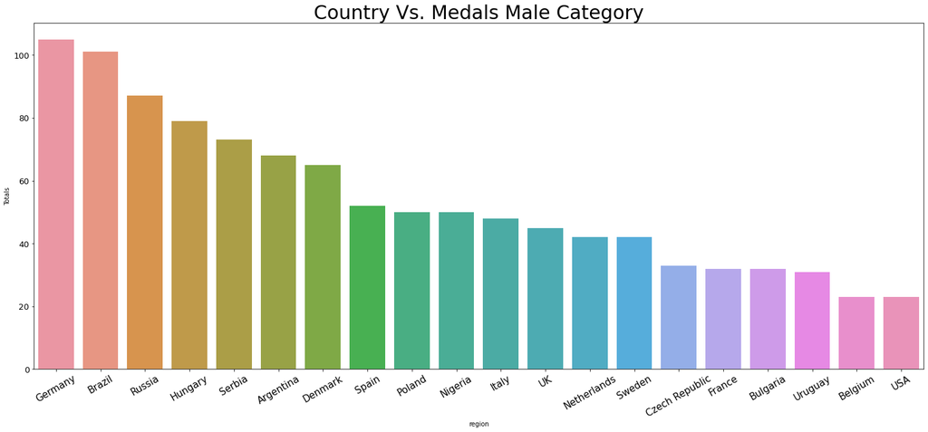

```python
m_map = male_football_medals.sort_values(by="Totals", ascending=False)[0:20]
fig = plt.figure(figsize=(25, 10))
g = sns.barplot(x = m_map.index, y = m_map["Totals"])
g.set_xticklabels(rotation = 30,
                 labels = m_map.index)
g.set_title ("Country Vs. Medals Male Category", fontdict={'size': 30})
plt.xticks(fontsize = 15)
plt.yticks(fontsize= 13)
plt.show()
```

### Notes from Male category

- *Germany is one of the countries when it comes to medal standing in the male category*
- *Interesting to note that we have countries such as Russia, Hungary and Serbia feature in the top 5*
- *Africa is well represented by Nigeria*

```python
female_gender = complete_data_new[complete_data_new["Sex"]=="F"]
female_gender_football = female_gender[female_gender["Sport"]=="Football"]
female_gender_football
```

|  | ID | Name | Sex | Age | Height | Weight | Team | NOC | Games | Year | Season | City | Sport | Event | Medal | region |
| --- | --- | --- | --- | --- | --- | --- | --- | --- | --- | --- | --- | --- | --- | --- | --- | --- |
| 24 | 6851 | Bai Jie | F | 28.0 | 163.0 | 53.0 | China | CHN | 2000 Summer | 2000 | Summer | Sydney | Football | Football Women's Football | NaN | China |
| 25 | 6853 | Bai Lili | F | 25.0 | 168.0 | 57.0 | China | CHN | 2004 Summer | 2004 | Summer | Athina | Football | Football Women's Football | NaN | China |
| 43 | 11224 | Bi Yan | F | 20.0 | 170.0 | 62.0 | China | CHN | 2004 Summer | 2004 | Summer | Athina | Football | Football Women's Football | NaN | China |
| 44 | 11224 | Bi Yan | F | 24.0 | 170.0 | 62.0 | China | CHN | 2008 Summer | 2008 | Summer | Beijing | Football | Football Women's Football | NaN | China |
| 314 | 20325 | Chen Yufeng | F | 26.0 | 165.0 | 55.0 | China | CHN | 1996 Summer | 1996 | Summer | Atlanta | Football | Football Women's Football | Silver | China |
| ... | ... | ... | ... | ... | ... | ... | ... | ... | ... | ... | ... | ... | ... | ... | ... | ... |
| 266816 | 74325 | Talent Mandaza | F | 30.0 | 158.0 | 60.0 | Zimbabwe | ZIM | 2016 Summer | 2016 | Summer | Rio de Janeiro | Football | Football Women's Football | NaN | Zimbabwe |
| 266861 | 83768 | Lynett Mutokuto | F | 27.0 | 161.0 | 56.0 | Zimbabwe | ZIM | 2016 Summer | 2016 | Summer | Rio de Janeiro | Football | Football Women's Football | NaN | Zimbabwe |
| 266865 | 83794 | Fedistas Muzongondi | F | 30.0 | 167.0 | 53.0 | Zimbabwe | ZIM | 2016 Summer | 2016 | Summer | Rio de Janeiro | Football | Football Women's Football | NaN | Zimbabwe |
| 266871 | 85356 | Rudo Neshamba | F | 24.0 | 164.0 | 53.0 | Zimbabwe | ZIM | 2016 Summer | 2016 | Summer | Rio de Janeiro | Football | Football Women's Football | NaN | Zimbabwe |
| 266883 | 87478 | Marjory Nyaumwe | F | 29.0 | 158.0 | 57.0 | Zimbabwe | ZIM | 2016 Summer | 2016 | Summer | Rio de Janeiro | Football | Football Women's Football | NaN | Zimbabwe |

1012 rows × 16 columns

```python
female_football_medals = female_gender_football.groupby("region")["Medal"].value_counts(dropna=False).unstack(fill_value=0)[["Gold", "Silver", "Bronze"]]
female_football_medals["Totals"] = female_football_medals["Gold"] + female_football_medals["Silver"] + female_football_medals["Bronze"]
female_football_medals.sort_values(by = "Totals", ascending=False)
```

| Medal region | Gold | Silver | Bronze | Totals |
| --- | --- | --- | --- | --- |
| USA | 66 | 13 | 0 | 79 |
| Germany | 18 | 0 | 50 | 68 |
| Canada | 0 | 0 | 36 | 36 |
| Brazil | 0 | 35 | 0 | 35 |
| Norway | 17 | 0 | 16 | 33 |
| Japan | 0 | 18 | 0 | 18 |
| Sweden | 0 | 18 | 0 | 18 |
| China | 0 | 15 | 0 | 15 |
| New Zealand | 0 | 0 | 0 | 0 |
| UK | 0 | 0 | 0 | 0 |
| South Africa | 0 | 0 | 0 | 0 |
| North Korea | 0 | 0 | 0 | 0 |
| Nigeria | 0 | 0 | 0 | 0 |
| Argentina | 0 | 0 | 0 | 0 |
| Mexico | 0 | 0 | 0 | 0 |
| Australia | 0 | 0 | 0 | 0 |
| Greece | 0 | 0 | 0 | 0 |
| France | 0 | 0 | 0 | 0 |
| Denmark | 0 | 0 | 0 | 0 |
| Colombia | 0 | 0 | 0 | 0 |
| Cameroon | 0 | 0 | 0 | 0 |
| Zimbabwe | 0 | 0 | 0 | 0 |

```python
len(female_football_medals[female_football_medals["Totals"] > 1])
```

```
8
```

**8 the number of countries to have won medals in the female category**

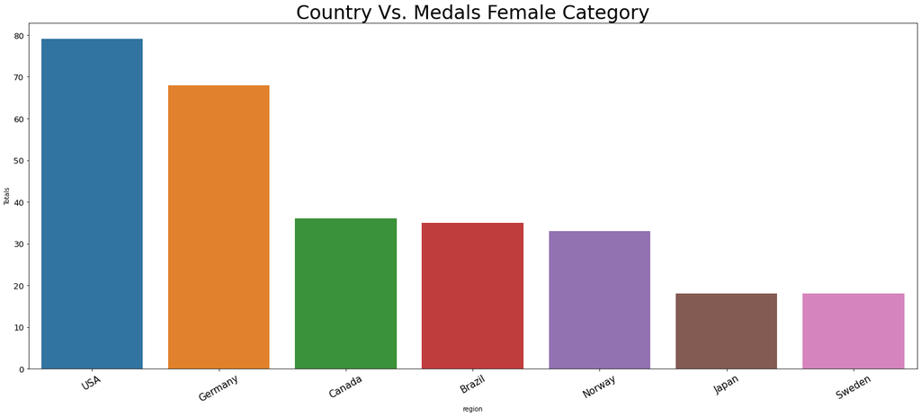

```python
f_map = female_football_medals.sort_values(by="Totals", ascending=False)[0:7]
fig = plt.figure(figsize=(25, 10))
g = sns.barplot(x = f_map.index, y = f_map["Totals"])
g.set_xticklabels(rotation = 30,
                 labels = f_map.index)
g.set_title ("Country Vs. Medals Female Category", fontdict={'size': 30})
plt.xticks(fontsize = 15)
plt.yticks(fontsize= 13)
plt.show()
```

# *Notes from the women Category*

- *Usa is dominant interms of the medals standing*
- *The other 7 countries are well known to be good football nations in the womens category*

# *Athletics is a field that so many countries take participation*

- *Focus will be to check on the Kenya as a country and the most decorated athletes*
- *Sprints for both male and female categories*
- *Successful countries in the sprints*

```python
athletics = complete_data_new[complete_data_new["Sport"]=="Athletics"]
number_of_Athletes = len(athletics["Name"].unique())
print(f"Total number of athletes to have ever participated: {number_of_Athletes}")
```

```
Total number of athletes to have ever participated: 22034
```

```python
athletics_medals = athletics.groupby("region")["Medal"].value_counts(dropna=False).unstack(fill_value=0)[["Gold", "Silver", "Bronze"]]
athletics_medals["Totals"] = athletics_medals['Gold'] + athletics_medals["Silver"] + athletics_medals["Bronze"]
athletics_medals.sort_values(by="Totals", ascending=False).head()
```

| Medal region | Gold | Silver | Bronze | Totals |
| --- | --- | --- | --- | --- |
| USA | 542 | 317 | 221 | 1080 |
| Russia | 124 | 129 | 121 | 374 |
| Germany | 90 | 132 | 143 | 365 |
| UK | 78 | 133 | 127 | 338 |
| Jamaica | 38 | 75 | 43 | 156 |

```python
print(len(athletics_medals["Totals"]),len(athletics_medals[athletics_medals["Totals"]>=1]))
```

```
203 90
```

**90 the number of countries that have a medal out of the 203 that have participated**

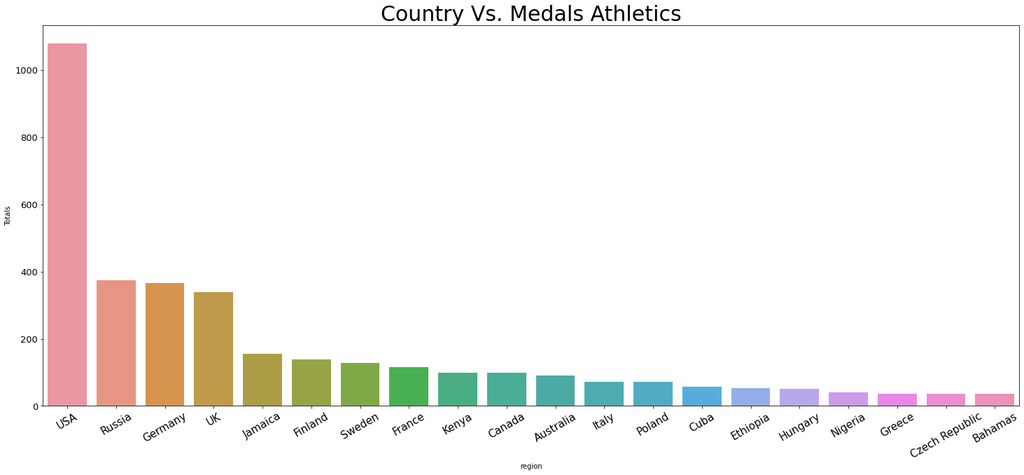

```python
a_map = athletics_medals.sort_values(by="Totals", ascending=False)[0:20]
fig = plt.figure(figsize=(25, 10))
g = sns.barplot(x = a_map.index, y = a_map["Totals"])
g.set_xticklabels(rotation = 30,
                 labels = a_map.index)
g.set_title ("Country Vs. Medals Athletics", fontdict={'size': 30})
plt.xticks(fontsize = 15)
plt.yticks(fontsize= 13)
plt.show()
```

### Sprinting 100M

- Athletics Men's 100 metres
- Athletics Women's 100 metres
- Athletics Men's 4 x 100 metres Relay
- Athletics Women's 4 x 100 metres Relay
- Athletics Women's 200 metres
- Athletics Men's 200 metres

```python
athletics['Event'].unique()
len(athletics['Event'].unique())
```

```
83
```

```python
men100 = athletics[athletics["Event"] =="Athletics Men's 100 metres"]
men100
```

|  | ID | Name | Sex | Age | Height | Weight | Team | NOC | Games | Year | Season | City | Sport | Event | Medal | region |
| --- | --- | --- | --- | --- | --- | --- | --- | --- | --- | --- | --- | --- | --- | --- | --- | --- |
| 54 | 17283 | Cai Jianming | M | 25.0 | 179.0 | 70.0 | China | CHN | 1988 Summer | 1988 | Summer | Seoul | Athletics | Athletics Men's 100 metres | NaN | China |
| 151 | 20193 | Chen Haijian | M | 24.0 | 176.0 | 60.0 | China | CHN | 2004 Summer | 2004 | Summer | Athina | Athletics | Athletics Men's 100 metres | NaN | China |
| 192 | 20228 | Chen Kingkwan | M | 23.0 | NaN | NaN | China | CHN | 1936 Summer | 1936 | Summer | Berlin | Athletics | Athletics Men's 100 metres | NaN | China |
| 246 | 20286 | Chen Wenzhong | M | 25.0 | 175.0 | 70.0 | China | CHN | 1996 Summer | 1996 | Summer | Atlanta | Athletics | Athletics Men's 100 metres | NaN | China |
| 975 | 50566 | Hu Kai | M | 26.0 | 182.0 | 80.0 | China | CHN | 2008 Summer | 2008 | Summer | Beijing | Athletics | Athletics Men's 100 metres | NaN | China |
| ... | ... | ... | ... | ... | ... | ... | ... | ... | ... | ... | ... | ... | ... | ... | ... | ... |
| 270704 | 59201 | Mothobi Kharitse | M | 23.0 | 175.0 | 73.0 | Lesotho | LES | 1988 Summer | 1988 | Summer | Seoul | Athletics | Athletics Men's 100 metres | NaN | Lesotho |
| 270709 | 68354 | Mosito Lehata | M | 27.0 | 177.0 | 69.0 | Lesotho | LES | 2016 Summer | 2016 | Summer | Rio de Janeiro | Athletics | Athletics Men's 100 metres | NaN | Lesotho |
| 270711 | 69045 | Joseph Letseka | M | 27.0 | 170.0 | 76.0 | Lesotho | LES | 1980 Summer | 1980 | Summer | Moskva | Athletics | Athletics Men's 100 metres | NaN | Lesotho |
| 270727 | 81698 | Motsapi Moorosi | M | 27.0 | 170.0 | 62.0 | Lesotho | LES | 1972 Summer | 1972 | Summer | Munich | Athletics | Athletics Men's 100 metres | NaN | Lesotho |
| 270753 | 109447 | Bothloko Shebe | M | 20.0 | 178.0 | 65.0 | Lesotho | LES | 1992 Summer | 1992 | Summer | Barcelona | Athletics | Athletics Men's 100 metres | NaN | Lesotho |

1928 rows × 16 columns

```python
male_100M_medals = men100.groupby("region")["Medal"].value_counts(dropna=False).unstack(fill_value=0)[["Gold", "Silver", "Bronze"]]
male_100M_medals["Totals"] = male_100M_medals["Gold"] + male_100M_medals["Silver"] + male_100M_medals["Bronze"]
male_100M_medals.sort_values(by = "Totals", ascending=False).head(18)
```

| Medal region | Gold | Silver | Bronze | Totals |
| --- | --- | --- | --- | --- |
| USA | 17 | 15 | 9 | 41 |
| Jamaica | 3 | 4 | 1 | 8 |
| UK | 3 | 2 | 3 | 8 |
| Canada | 2 | 0 | 4 | 6 |
| Germany | 1 | 1 | 2 | 4 |
| Trinidad | 1 | 2 | 1 | 4 |
| Australia | 0 | 0 | 3 | 3 |
| Russia | 1 | 0 | 1 | 2 |
| Namibia | 0 | 2 | 0 | 2 |
| Cuba | 0 | 2 | 0 | 2 |
| South Africa | 1 | 0 | 0 | 1 |
| Panama | 0 | 0 | 1 | 1 |
| Hungary | 0 | 0 | 1 | 1 |
| Barbados | 0 | 0 | 1 | 1 |
| New Zealand | 0 | 0 | 1 | 1 |
| Netherlands | 0 | 0 | 1 | 1 |
| Bulgaria | 0 | 0 | 1 | 1 |
| Portugal | 0 | 1 | 0 | 1 |

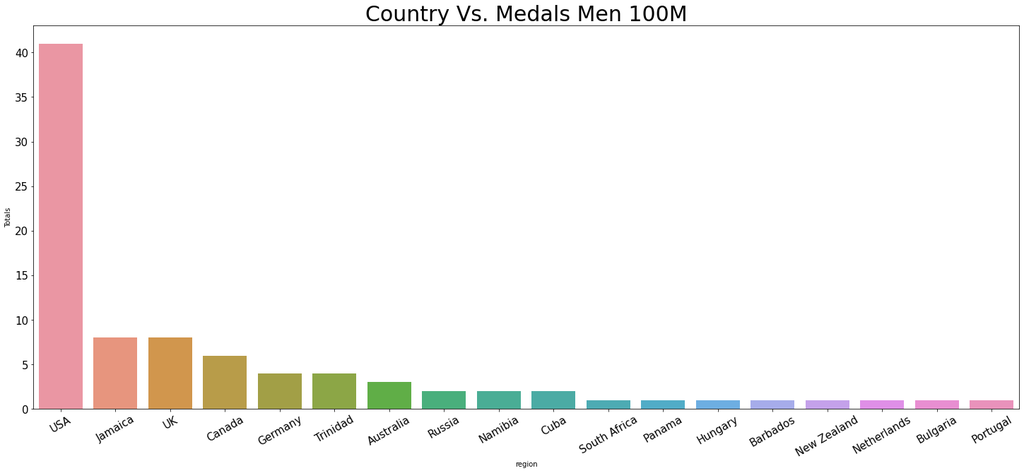

```python
a_100_map = male_100M_medals.sort_values(by="Totals", ascending=False)[0:18]
fig = plt.figure(figsize=(25, 10))
g = sns.barplot(x = a_100_map.index, y = a_100_map["Totals"])
g.set_xticklabels(rotation = 30,
                 labels = a_100_map.index)
g.set_title ("Country Vs. Medals Men 100M", fontdict={'size': 30})
plt.xticks(fontsize = 15)
plt.yticks(fontsize= 15)
plt.show()
```

## Notes from 100M Men

- USA are the most dominant country when it comes to 100M sprint
- Important to note africa is represented as well by Namibia

```python
male_100M_medals = men100.groupby("Name")["Medal"].value_counts(dropna=False).unstack(fill_value=0)[["Gold", "Silver", "Bronze"]]
male_100M_medals["Totals"] = male_100M_medals["Gold"] + male_100M_medals["Silver"] + male_100M_medals["Bronze"]
male_100M_medals.sort_values(by = "Totals", ascending=False).head(5)
```

| Medal Name | Gold | Silver | Bronze | Totals |
| --- | --- | --- | --- | --- |
| Justin Alexander Gatlin | 1 | 1 | 1 | 3 |
| Usain St. Leo Bolt | 3 | 0 | 0 | 3 |
| Frank "Frankie" Fredericks | 0 | 2 | 0 | 2 |
| Ralph Harold Metcalfe | 0 | 2 | 0 | 2 |
| Linford Ecerio Christie | 1 | 1 | 0 | 2 |

```python
men200 = athletics[athletics["Event"] =="Athletics Men's 200 metres"]
men200.head()
```

|  | ID | Name | Sex | Age | Height | Weight | Team | NOC | Games | Year | Season | City | Sport | Event | Medal | region |
| --- | --- | --- | --- | --- | --- | --- | --- | --- | --- | --- | --- | --- | --- | --- | --- | --- |
| 193 | 20228 | Chen Kingkwan | M | 23.0 | NaN | NaN | China | CHN | 1936 Summer | 1936 | Summer | Berlin | Athletics | Athletics Men's 200 metres | NaN | China |
| 247 | 20286 | Chen Wenzhong | M | 25.0 | 175.0 | 70.0 | China | CHN | 1996 Summer | 1996 | Summer | Atlanta | Athletics | Athletics Men's 200 metres | NaN | China |
| 1409 | 69344 | Li Feng | M | 23.0 | 180.0 | 75.0 | China | CHN | 1988 Summer | 1988 | Summer | Seoul | Athletics | Athletics Men's 200 metres | NaN | China |
| 1970 | 70551 | Liu Changchun | M | 22.0 | NaN | NaN | China | CHN | 1932 Summer | 1932 | Summer | Los Angeles | Athletics | Athletics Men's 200 metres | NaN | China |
| 1972 | 70551 | Liu Changchun | M | 26.0 | NaN | NaN | China | CHN | 1936 Summer | 1936 | Summer | Berlin | Athletics | Athletics Men's 200 metres | NaN | China |

```python
male_200M_medals = men200.groupby("region")["Medal"].value_counts(dropna=False).unstack(fill_value=0)[["Gold", "Silver", "Bronze"]]
male_200M_medals["Totals"] = male_200M_medals["Gold"] + male_200M_medals["Silver"] + male_200M_medals["Bronze"]
male_200M_medals.sort_values(by = "Totals", ascending=False).head(5)
```

| Medal region | Gold | Silver | Bronze | Totals |
| --- | --- | --- | --- | --- |
| USA | 17 | 18 | 11 | 46 |
| Jamaica | 4 | 1 | 2 | 7 |
| UK | 0 | 3 | 3 | 6 |
| Italy | 2 | 0 | 1 | 3 |
| Canada | 2 | 1 | 0 | 3 |

```python
male_200M_medals = men200.groupby("Name")["Medal"].value_counts(dropna=False).unstack(fill_value=0)[["Gold", "Silver", "Bronze"]]
male_200M_medals["Totals"] = male_200M_medals["Gold"] + male_200M_medals["Silver"] + male_200M_medals["Bronze"]
male_200M_medals.sort_values(by = "Totals", ascending=False).head(5)
```

| Medal Name | Gold | Silver | Bronze | Totals |
| --- | --- | --- | --- | --- |
| Usain St. Leo Bolt | 3 | 0 | 0 | 3 |
| Shawn Crawford | 1 | 1 | 0 | 2 |
| Ato Jabari Boldon | 0 | 0 | 2 | 2 |
| Donald O'Reilly "Don" Quarrie | 1 | 0 | 1 | 2 |
| Pietro Paolo Mennea | 1 | 0 | 1 | 2 |

```python
# Athletics Women's 100 metres
# Athletics Women's 200 metres
```

```python
women100 = athletics[athletics["Event"] =="Athletics Women's 100 metres"]
women100.head()
```

|  | ID | Name | Sex | Age | Height | Weight | Team | NOC | Games | Year | Season | City | Sport | Event | Medal | region |
| --- | --- | --- | --- | --- | --- | --- | --- | --- | --- | --- | --- | --- | --- | --- | --- | --- |
| 645 | 38404 | Gao Han | F | 21.0 | 171.0 | 54.0 | China | CHN | 1992 Summer | 1992 | Summer | Barcelona | Athletics | Athletics Women's 100 metres | NaN | China |
| 1637 | 69480 | Li Sen | F | 22.0 | 168.0 | NaN | China | CHN | 1936 Summer | 1936 | Summer | Berlin | Athletics | Athletics Women's 100 metres | NaN | China |
| 1758 | 69538 | Li Xuemei | F | 23.0 | 171.0 | 61.0 | China | CHN | 2000 Summer | 2000 | Summer | Sydney | Athletics | Athletics Women's 100 metres | NaN | China |
| 1760 | 69538 | Li Xuemei | F | 27.0 | 171.0 | 61.0 | China | CHN | 2004 Summer | 2004 | Summer | Athina | Athletics | Athletics Women's 100 metres | NaN | China |
| 2085 | 70634 | Liu Shaomei | F | 24.0 | 162.0 | 52.0 | China | CHN | 1988 Summer | 1988 | Summer | Seoul | Athletics | Athletics Women's 100 metres | NaN | China |

## Women 100M perfromance

```python
female_100M_medals = women100.groupby("region")["Medal"].value_counts(dropna=False).unstack(fill_value=0)[["Gold", "Silver", "Bronze"]]
female_100M_medals["Totals"] = female_100M_medals["Gold"] + female_100M_medals["Silver"] + female_100M_medals["Bronze"]
female_100M_medals.sort_values(by = "Totals", ascending=False).head(5)
```

| Medal region | Gold | Silver | Bronze | Totals |
| --- | --- | --- | --- | --- |
| USA | 9 | 7 | 2 | 18 |
| Jamaica | 3 | 5 | 5 | 13 |
| Germany | 2 | 3 | 4 | 9 |
| Australia | 2 | 1 | 3 | 6 |
| Poland | 1 | 1 | 2 | 4 |

```python
female_100M_medals = women100.groupby("Name")["Medal"].value_counts(dropna=False).unstack(fill_value=0)[["Gold", "Silver", "Bronze"]]
female_100M_medals["Totals"] = female_100M_medals["Gold"] + female_100M_medals["Silver"] + female_100M_medals["Bronze"]
female_100M_medals.sort_values(by = "Totals", ascending=False).head(5)
```

| Medal Name | Gold | Silver | Bronze | Totals |
| --- | --- | --- | --- | --- |
| Shelly-Ann Fraser-Pryce | 2 | 0 | 1 | 3 |
| Merlene Joyce Ottey-Page | 0 | 1 | 2 | 3 |
| Stanisawa Walasiewicz (-Walsh, -Olson) | 1 | 1 | 0 | 2 |
| Shirley Barbara Strickland de la Hunty | 0 | 0 | 2 | 2 |
| Veronica Angella Campbell-Brown | 0 | 0 | 2 | 2 |

### Kenya olympics athletics competition

```python
kenya_perf = complete_data_new[complete_data_new["region"]=="Kenya"]
kenya_perf.head()
```

|  | ID | Name | Sex | Age | Height | Weight | Team | NOC | Games | Year | Season | City | Sport | Event | Medal | region |
| --- | --- | --- | --- | --- | --- | --- | --- | --- | --- | --- | --- | --- | --- | --- | --- | --- |
| 199359 | 442 | Catherine "Kate" Abilla Awino | F | 27.0 | 162.0 | 56.0 | Kenya | KEN | 2016 Summer | 2016 | Summer | Rio de Janeiro | Rugby Sevens | Rugby Sevens Women's Rugby Sevens | NaN | Kenya |
| 199360 | 603 | Juma Abudu | M | 24.0 | 170.0 | 59.0 | Kenya | KEN | 1988 Summer | 1988 | Summer | Seoul | Weightlifting | Weightlifting Men's Featherweight | NaN | Kenya |
| 199361 | 779 | Shuaib Adam | M | 30.0 | 175.0 | 80.0 | Kenya | KEN | 1984 Summer | 1984 | Summer | Los Angeles | Shooting | Shooting Men's Free Pistol, 50 metres | NaN | Kenya |
| 199362 | 779 | Shuaib Adam | M | 35.0 | 175.0 | 80.0 | Kenya | KEN | 1988 Summer | 1988 | Summer | Seoul | Shooting | Shooting Men's Air Pistol, 10 metres | NaN | Kenya |
| 199363 | 779 | Shuaib Adam | M | 35.0 | 175.0 | 80.0 | Kenya | KEN | 1988 Summer | 1988 | Summer | Seoul | Shooting | Shooting Men's Free Pistol, 50 metres | NaN | Kenya |

```python
ath_kenya = len(kenya_perf["Name"].unique())
print(f"Upto 2016 kenya had sent through {ath_kenya} athletes to the olympics competition")
```

```
Upto 2016 kenya had sent through 515 athletes to the olympics competition
```

```python
athletics_medals_kenya = kenya_perf.groupby("region")["Medal"].value_counts(dropna=False).unstack(fill_value=0)[["Gold", "Silver", "Bronze"]]
athletics_medals_kenya["Totals"] = athletics_medals_kenya['Gold'] + athletics_medals_kenya["Silver"] + athletics_medals_kenya["Bronze"]
athletics_medals_kenya.sort_values(by="Totals", ascending=False).head()
```

| Medal region | Gold | Silver | Bronze | Totals |
| --- | --- | --- | --- | --- |
| Kenya | 34 | 41 | 31 | 106 |

#### *Kenya has bagged 106 medals till the olympics of 2016*

```python
athletics_medals_kenya_athletes = kenya_perf.groupby("Name")["Medal"].value_counts(dropna=False).unstack(fill_value=0)[["Gold", "Silver", "Bronze"]]
athletics_medals_kenya_athletes["Totals"] = athletics_medals_kenya_athletes['Gold'] + athletics_medals_kenya_athletes["Silver"] + athletics_medals_kenya_athletes["Bronze"]
athletics_medals_kenya_athletes.sort_values(by="Totals", ascending=False).head(10)
```

| Medal Name | Gold | Silver | Bronze | Totals |
| --- | --- | --- | --- | --- |
| Vivian Jepkemoi Cheruiyot | 1 | 2 | 1 | 4 |
| Kipchoge Hezekieh "Kip" Keino | 2 | 2 | 0 | 4 |
| Eliud Kipchoge | 1 | 1 | 1 | 3 |
| Nabiba Naftali Temu | 1 | 0 | 1 | 2 |
| Philip Waruinge | 0 | 1 | 1 | 2 |
| Erick Wainaina | 0 | 1 | 1 | 2 |
| Julius Sang | 1 | 0 | 1 | 2 |
| Paul Kibii Tergat | 0 | 2 | 0 | 2 |
| Hezekiah Munyoro Nyamau | 1 | 1 | 0 | 2 |
| Brimin Kiprop (Firmin-) Kipruto | 1 | 1 | 0 | 2 |

```python
athletics_medals_kenya_sport = kenya_perf.groupby("Sport")["Medal"].value_counts(dropna=False).unstack(fill_value=0)[["Gold", "Silver", "Bronze"]]
athletics_medals_kenya_sport["Totals"] = athletics_medals_kenya_sport['Gold'] + athletics_medals_kenya_sport["Silver"] + athletics_medals_kenya_sport["Bronze"]
athletics_medals_kenya_sport.sort_values(by="Totals", ascending=False).head()
```

| Medal Sport | Gold | Silver | Bronze | Totals |
| --- | --- | --- | --- | --- |
| Athletics | 33 | 40 | 26 | 99 |
| Boxing | 1 | 1 | 5 | 7 |
| Archery | 0 | 0 | 0 | 0 |
| Cross Country Skiing | 0 | 0 | 0 | 0 |
| Cycling | 0 | 0 | 0 | 0 |

#### *Kenya has had more success in athletics as compared to the other disciplines*

### Conclusions

###### 1. Olympics is a huge competition and over the years, this event has entertained me and even made me appreciate sports in general and as well take the journey to exrecise and pull few kilometres every new week.

###### 2. Sports is what pull the community together, we have seen instances where the community and even the entire country rally behind their own.

###### 3. The data has uncovered alot in terms of how the countries have faired and as well the most successfully athletes in the selected disciplines.

###### 4. Exploratory analysis is the start of some much, focus is to now dig the various features and make interesting conclusions, the various disciplines calls on alot of exercise but also there are other things that data can helps to uncover.